# Module 04: SEM, Regression, and Causal Inference

# 6 Part E: Difference-in-Differences

## 6.1 The Basic 2×2 DiD Design

The simplest DiD design has two groups (treated and control) and two time periods (before and after treatment). The logic:

The 2×2 DiD Design: How the Estimator Works

| Group | Before | After | DiD (After-Before) |
| --- | --- | --- | --- |
| Treated | μ(T, pre) | μ(T, post) | μ(T,post) − μ(T,pre) |
| Control | μ(C, pre) | μ(C, post) | μ(C,post) − μ(C,pre) |
| Difference | μ(T,pre) − μ(C,pre) | μ(T,post) − μ(C,post) | [μ(T,post)−μ(T,pre)] − [μ(C,post)−μ(C,pre)] = Treatment Effect |

Note:  
The DiD estimator = (post-pre change for treated) minus (post-pre change for control). Subtracting the control group’s change removes time trends common to both groups. This works IF the two groups would have followed the same trend without treatment (parallel trends).

**The parallel trends assumption** is the identifying assumption: in the absence of treatment, the treated and control groups would have changed by the same amount over the same period. This cannot be tested directly (we cannot observe the counterfactual), but we can *assess* it by checking whether the groups followed parallel trends *before* treatment.

```r
# Illustrate with a concrete 2x2 DiD calculation
# Scenario: A city introduces a job training programme in 2015
# We observe employment rates in 2012 (pre) and 2018 (post)

did_data <- tibble(
  group  = c("Treated","Treated","Control","Control"),
  period = c("2012 (pre)","2018 (post)","2012 (pre)","2018 (post)"),
  emp_rate = c(58.2, 63.7, 60.1, 62.4)  # % employed
)

cat("=== 2×2 DiD Calculation ===\n\n")
```

```
## === 2×2 DiD Calculation ===
```

```r
cat("Employment rates (%):\n")
```

```
## Employment rates (%):
```

```r
did_data |>
  pivot_wider(names_from=period, values_from=emp_rate) |>
  mutate(`Change (post-pre)` = `2018 (post)` - `2012 (pre)`) |>
  print()
```

```
## # A tibble: 2 × 4
##   group   `2012 (pre)` `2018 (post)` `Change (post-pre)`
##   <chr>          <dbl>         <dbl>               <dbl>
## 1 Treated         58.2          63.7                5.5
## 2 Control         60.1          62.4                2.30
```

```r
# Compute the DiD estimate
treated_change <- 63.7 - 58.2   # = 5.5
control_change <- 62.4 - 60.1   # = 2.3
did_estimate   <- treated_change - control_change  # = 3.2

cat("\nTreated group change: 63.7 - 58.2 =", treated_change, "pp\n")
```

```
##
## Treated group change: 63.7 - 58.2 = 5.5 pp
```

```r
cat("Control group change: 62.4 - 60.1 =", control_change, "pp\n")
```

```
## Control group change: 62.4 - 60.1 = 2.3 pp
```

```r
cat("DiD estimate:          ", treated_change, "-", control_change,
    "=", did_estimate, "percentage points\n\n")
```

```
## DiD estimate:           5.5 - 2.3 = 3.2 percentage points
```

```r
cat("Interpretation: The job training programme increased employment by",
    did_estimate, "percentage points\n")
```

```
## Interpretation: The job training programme increased employment by 3.2 percentage points
```

```r
cat("on average, above and beyond the", control_change,
    "pp increase that would have occurred anyway (the common time trend).\n")
```

```
## on average, above and beyond the 2.3 pp increase that would have occurred anyway (the common time trend).
```

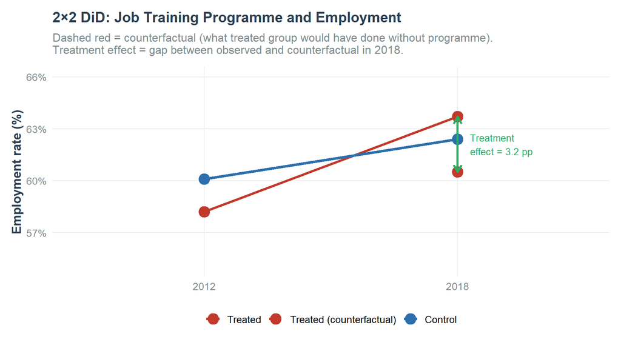

```r
# Visualise the 2x2 DiD logic
did_plot_df <- bind_rows(
  did_data,
  # Add the counterfactual: treated group following control group's trend
  tibble(
    group    = "Treated (counterfactual)",
    period   = "2018 (post)",
    emp_rate = 58.2 + control_change  # = 60.5: what treated would have been without programme
  )
)

ggplot(
  did_plot_df |> mutate(
    time    = factor(str_extract(period,"\\d{4}"), levels=c("2012","2018")),
    group_f = factor(group, levels=c("Treated","Treated (counterfactual)","Control"))
  ),
  aes(x=time, y=emp_rate, colour=group_f, group=group_f)
) +
  geom_line(aes(linetype=group_f), linewidth=1.3) +
  geom_point(size=5) +
  # Annotate the treatment effect
  annotate("segment",
           x=2, xend=2, y=60.5, yend=63.7,
           arrow=arrow(length=unit(0.3,"cm"), ends="both"),
           colour="#27AE60", linewidth=1.2) +
  annotate("text", x=2.05, y=62.1, label=paste0("Treatment\neffect = ",
           did_estimate, " pp"), hjust=0, colour="#27AE60", size=3.5) +
  scale_colour_manual(
    values=c("Treated"="#C0392B","Treated (counterfactual)"="#C0392B","Control"="#2C6FAC"),
    name=NULL) +
  scale_linetype_manual(values=c("Treated"="solid","Treated (counterfactual)"="dashed","Control"="solid"),
                        name=NULL) +
  scale_y_continuous(labels=\(x) paste0(x,"%"), limits=c(55,66)) +
  labs(
    title    = "2×2 DiD: Job Training Programme and Employment",
    subtitle = paste("Dashed red = counterfactual (what treated group would have done without programme).",
                     "\nTreatment effect = gap between observed and counterfactual in 2018."),
    x=NULL, y="Employment rate (%)"
  ) +
  theme(legend.position="bottom")
```

## 6.2 Regression Implementation of DiD

In practice, DiD is estimated by a regression with an interaction term:

```r
# Simulate a small dataset for the regression version
set.seed(2024)
did_reg_data <- tibble(
  id      = 1:200,
  treated = rep(c(1,0), each=100),
  post    = rep(c(0,1,0,1), each=50),
  # Outcome with true treatment effect of 3.2
  outcome = 58 + 2*treated + 2.3*post + 3.2*treated*post + rnorm(200, 0, 3)
)

# The DiD estimator is the coefficient on treated × post
did_model <- lm(outcome ~ treated + post + treated:post, data=did_reg_data)
summary(did_model)
```

```
##
## Call:
## lm(formula = outcome ~ treated + post + treated:post, data = did_reg_data)
##
## Residuals:
##     Min      1Q  Median      3Q     Max
## -9.5960 -2.0661  0.1064  2.2424  6.5475
##
## Coefficients:
##              Estimate Std. Error t value Pr(>|t|)
## (Intercept)   58.0785     0.4346 133.641  < 2e-16 ***
## treated        1.6947     0.6146   2.757  0.00638 **
## post           2.9354     0.6146   4.776 3.49e-06 ***
## treated:post   2.5087     0.8692   2.886  0.00434 **
## ---
## Signif. codes:  0 '***' 0.001 '**' 0.01 '*' 0.05 '.' 0.1 ' ' 1
##
## Residual standard error: 3.073 on 196 degrees of freedom
## Multiple R-squared:  0.4291, Adjusted R-squared:  0.4204
## F-statistic: 49.11 on 3 and 196 DF,  p-value: < 2.2e-16
```

```r
cat("\nDiD interpretation of coefficients:\n")
```

```
##
## DiD interpretation of coefficients:
```

```r
cat("  (Intercept)  = control group mean in the pre period\n")
```

```
##   (Intercept)  = control group mean in the pre period
```

```r
cat("  treated      = pre-period difference between treated and control (at baseline)\n")
```

```
##   treated      = pre-period difference between treated and control (at baseline)
```

```r
cat("  post         = time trend for the control group (common time effect)\n")
```

```
##   post         = time trend for the control group (common time effect)
```

```r
cat("  treated:post = THE DiD ESTIMATE = treatment effect\n\n")
```

```
##   treated:post = THE DiD ESTIMATE = treatment effect
```

```r
cat("The treated:post coefficient should be ~3.2 (the true effect we simulated).\n")
```

```
## The treated:post coefficient should be ~3.2 (the true effect we simulated).
```

```r
cat("Observed:", round(coef(did_model)["treated:post"], 2), "\n")
```

```
## Observed: 2.51
```

## 6.3 Event Study / Staggered Treatment

When treatment is adopted at different times by different units, we use an event study design with two-way fixed effects:

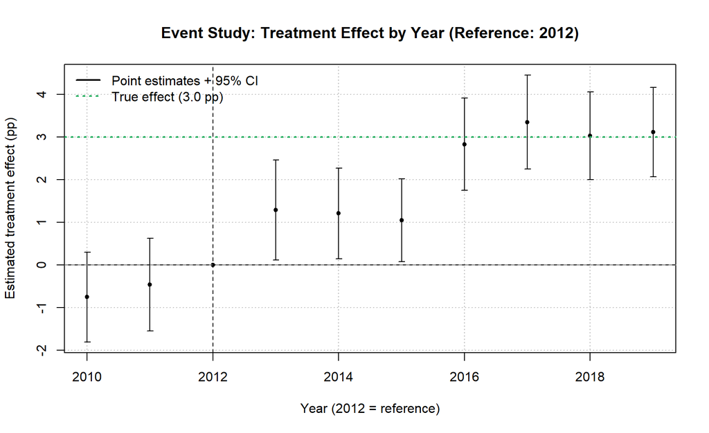

```r
set.seed(2024)
n_counties <- 60; n_years <- 10

panel_df <- expand_grid(county=1:n_counties, year=2010:2019) |>
  mutate(
    treated    = county <= 30,
    treat_year = ifelse(!treated, 0L, ifelse(county <= 15, 2013L, 2016L)),
    post       = as.integer(year >= treat_year & treat_year > 0),
    treat_eff  = post * (3.0 + rnorm(n(), 0, 0.3)),
    county_fe  = rep(rnorm(n_counties, 0, 2), each=n_years),
    outcome    = 50 + 0.5*(year-2010) + county_fe + treat_eff + rnorm(n(), 0, 1.5)
  )

library(fixest)
es_model <- feols(
  outcome ~ i(year, treated, ref=2012) | county + year,
  data=panel_df, cluster=~county
)

iplot(es_model,
      main  = "Event Study: Treatment Effect by Year (Reference: 2012)",
      xlab  = "Year (2012 = reference)",
      ylab  = "Estimated treatment effect (pp)",
      ci_level = 0.95)
abline(h=0, lty=2, col="grey50")
abline(h=3.0, lty=3, col="#27AE60", lwd=2)
legend("topleft", c("Point estimates + 95% CI","True effect (3.0 pp)"),
       lty=c(1,3), col=c("black","#27AE60"), lwd=2, bty="n")
```

# 7 Part F: Propensity Score Matching

## 7.1 The Logic

When you cannot randomise and DiD is unavailable (no natural experiment), **propensity score matching (PSM)** attempts to control confounding by constructing a comparison group that looks similar to the treated group on observed characteristics.

The propensity score $p(x) = P(\text{treated}=1 | X=x)$ is estimated using logistic regression. Treated and control units with similar propensity scores are matched. After matching, the matched sample should look like a (imperfect) experiment.

**Key assumption:** No unmeasured confounding. All variables that affect both treatment assignment and the outcome must be in the model. This cannot be tested — it must be justified theoretically.

```r
library(MatchIt)
set.seed(2024)
n <- 1000

obs_data <- tibble(
  ses     = rnorm(n),
  ability = rnorm(n),
  college = rbinom(n, 1, plogis(-0.3 + 1.0*ses + 0.8*ability)),
  income  = 40 + 8*college + 5*ses + 3*ability + rnorm(n, 0, 5)
)

cat("=== Observational Data ===\n")
```

```
## === Observational Data ===
```

```r
cat("N:", nrow(obs_data), "| True college premium: $8,000\n")
```

```
## N: 1000 | True college premium: $8,000
```

```r
cat("Naive comparison:\n")
```

```
## Naive comparison:
```

```r
obs_data |>
  group_by(college) |>
  summarise(mean_inc=round(mean(income),2), n=n()) |>
  mutate(diff=c(NA, diff(mean_inc))) |>
  print()
```

```
## # A tibble: 2 × 4
##   college mean_inc     n  diff
##     <int>    <dbl> <int> <dbl>
## 1       0     37.6   576  NA
## 2       1     51.2   424  13.6
```

```r
cat("→ Naive estimate inflated by confounding (high-SES, high-ability more likely to go to college)\n\n")
```

```
## → Naive estimate inflated by confounding (high-SES, high-ability more likely to go to college)
```

```r
# Match on ses and ability (the confounders)
match_out <- matchit(college ~ ses + ability, data=obs_data,
                     method="nearest", ratio=1, replace=FALSE)
summary(match_out)
```

```
##
## Call:
## matchit(formula = college ~ ses + ability, data = obs_data, method = "nearest",
##     replace = FALSE, ratio = 1)
##
## Summary of Balance for All Data:
##          Means Treated Means Control Std. Mean Diff. Var. Ratio eCDF Mean
## distance        0.5628        0.3218          1.0868     1.1932    0.2863
## ses             0.4599       -0.3306          0.8653     1.0453    0.2332
## ability         0.3281       -0.1968          0.5461     1.0907    0.1514
##          eCDF Max
## distance   0.4379
## ses        0.3605
## ability    0.2375
##
## Summary of Balance for Matched Data:
##          Means Treated Means Control Std. Mean Diff. Var. Ratio eCDF Mean
## distance        0.5628        0.3974          0.7459     1.4645    0.1842
## ses             0.4599       -0.0271          0.5331     1.4038    0.1449
## ability         0.3281       -0.0147          0.3566     1.2106    0.1005
##          eCDF Max Std. Pair Dist.
## distance   0.3443          0.7461
## ses        0.2618          0.8308
## ability    0.1769          1.0125
##
## Sample Sizes:
##           Control Treated
## All           576     424
## Matched       424     424
## Unmatched     152       0
## Discarded       0       0
```

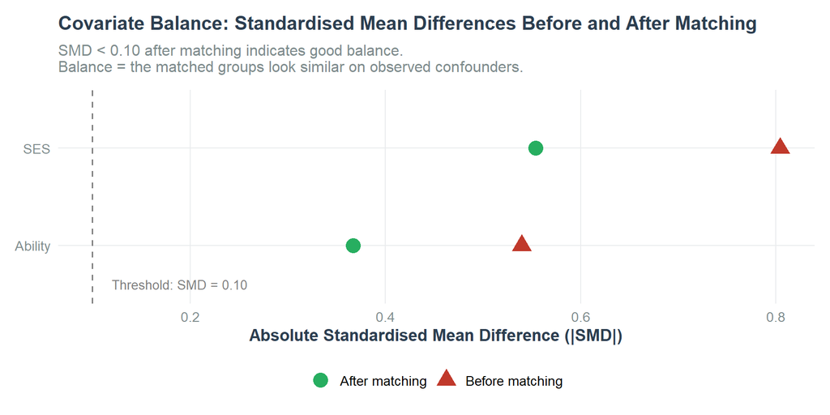

```r
# Visualise balance: before vs. after matching
match_df <- match.data(match_out)

# Standardised mean differences (SMD) — should be < 0.10 after matching
smd_before <- obs_data |>
  group_by(college) |>
  summarise(m_ses=mean(ses), m_ab=mean(ability)) |>
  summarise(smd_ses=diff(m_ses)/sd(obs_data$ses),
            smd_ab=diff(m_ab)/sd(obs_data$ability))

smd_after <- match_df |>
  group_by(college) |>
  summarise(m_ses=mean(ses), m_ab=mean(ability)) |>
  summarise(smd_ses=diff(m_ses)/sd(match_df$ses),
            smd_ab=diff(m_ab)/sd(match_df$ability))

smd_df <- bind_rows(
  tibble(Stage="Before matching", Variable=c("SES","Ability"),
         SMD=c(smd_before$smd_ses, smd_before$smd_ab)),
  tibble(Stage="After matching",  Variable=c("SES","Ability"),
         SMD=c(smd_after$smd_ses, smd_after$smd_ab))
)

ggplot(smd_df, aes(x=abs(SMD), y=Variable, colour=Stage, shape=Stage)) +
  geom_vline(xintercept=0.10, linetype="dashed", colour="grey50") +
  geom_point(size=5) +
  scale_colour_manual(values=c("Before matching"="#C0392B","After matching"="#27AE60"),
                      name=NULL) +
  scale_shape_manual(values=c(16,17), name=NULL) +
  annotate("text", x=0.12, y=0.6, label="Threshold: SMD = 0.10",
           hjust=0, colour="grey50", size=3.5) +
  labs(
    title    = "Covariate Balance: Standardised Mean Differences Before and After Matching",
    subtitle = paste("SMD < 0.10 after matching indicates good balance.",
                     "\nBalance = the matched groups look similar on observed confounders."),
    x="Absolute Standardised Mean Difference (|SMD|)", y=NULL
  ) +
  theme(legend.position="bottom")
```

```r
# Treatment effect estimate from matched sample
psm_model <- lm(income ~ college, data=match_df, weights=weights)
cat("PSM estimate of college income premium: $",
    round(coef(psm_model)["college"],2), "\n")
```

```
## PSM estimate of college income premium: $ 11.56
```

```r
cat("True effect: $8,000\n")
```

```
## True effect: $8,000
```

```r
cat("Remaining gap reflects imperfect matching or sampling variation.\n")
```

```
## Remaining gap reflects imperfect matching or sampling variation.
```